# Exploring the BRFSS data

## Setup

### Load packages

```r
#install.packages("ggpubr")
library(ggplot2)
library(dplyr)
library("ggpubr")
library(data.table)
```

### Load data

Make sure your data and R Markdown files are in the same directory. When loaded your data file will be called `brfss2013`. Delete this note when before you submit your work.

```r
load("brfss2013.RData")
#head(brfss2013)
```

## Part 1: Data

#### Describe how the observations in the sample are collected, and the implications of this data collection method on the scope of inference (generalizability / causality). Note that you will need to look into documentation on the BRFSS to answer this question. See http://www.cdc.gov/brfss/ as well as the “More information on the data” section below.

What is The Behavioral Risk Factor Surveillance System (BRFSS)? - According to http://www.cdc.gov/brfss/, ‘The Behavioral Risk Factor Surveillance System (BRFSS) is the nation’s premier system of health-related telephone surveys that collect state data about U.S. residents regarding their health-related risk behaviors, chronic health conditions, and use of preventive services. BRFSS is an ongoing surveillance system designed to measure behavioral risk factors for the non-institutionalized adult population (18 years of age and older) residing in the US.’

What factors is the goal of BRFSS and what factors it cares about? - The BRFSS objective is to collect uniform, state-specific data on preventive health practices and risk behaviors that are linked to chronic diseases, injuries, and preventable infectious diseases that affect the adult population.

- Factors assessed by the BRFSS in 2013 include tobacco use, HIV/AIDS knowledge and prevention, exercise, immunization, health status, healthy days — health-related quality of life, health care access, inadequate sleep, hypertension awareness, cholesterol awareness, chronic health conditions, alcohol consumption, fruits and vegetables consumption, arthritis burden, and seatbelt use.

How is the data collected? - BRFSS was initiated in 1984, and the data is collective through monthly telephone interviews. - And since 2011, BRFSS starts to collect surveys through both telephone and mobile phones.

- The data was initially sampled from 15 states, and now 53 states and districts (Guam pureto rico and D.C.) joined this program. So the data might include more samples from states joined earlier.
- In conducting the BRFSS landline telephone survey, interviewers collect data from a randomly selected adult in a household. In conducting the cellular telephone version of the BRFSS questionnaire, interviewers collect data from an adult who participates by using a cellular telephone and resides in a private residence or college housing.
- All data are collected from adult population.

Discussion: - The data is collected through landline or mobile phones which means the samples only comes from people with a landline or mobile phones. - The data might be biased to people who willing to answer the phone or complete the survey. It is a very long survey, there might be some statistic distributions among people who are willing to complete the survey. For example, people who are very busy might not will to take a long survey or just do not pay much attention to it. - In addition, many of the questions aim to get the information for the past 30 days. Responders may not have a good memory about those questions (e.g how many days you feel sad in the past 30 days). - Another issues is sometimes the response might be biased to more recent event. For example, one might respond they don’t have sleep problems issues simply because they have some good sleep this week. - Considering these limitations, one should be carefully consider those bias before use the data. * * *

## Part 2: Research questions

**Research quesion 1:** - is Physical Activity associated with physical health status and mental health status? - Variables: - physhlth: days per month - menthlth: days per month - exercise frequency: - exeroft1: Times - exerhmm1: hours and minutes - exeroft2: Times - exerhmm2: hours and minutes - strength: Times

- physhlth
- menthlth
- times of exercise: freqexer
  - exeroft1, exeroft2, strength

Relevance: Many people argues that exercise is important for both mental health and physcial health are important to people. It would be a solid evidence of that calim if we could show there that more exercise leads to lower mental unwellness days and physical unwellness days.

**Research quesion 2:**

- How dose diabete relate with body fat (weight, height, BMI) and sex?
- Variables:
  - _bmi5 : weight and height are correlated variables, instead of using raw height and weight, we use BMI to represent the objects’ body fat condition.
  - sex
  - diabetes3: (Ever Told You Have Diabetes)
    - For simplicity, we only consider objects in diabete 3 that answered yes or no.

**Research question 3:**

Ho: Null Hypothesis, there is no statistically significant relationship between them. Ha: Alternative Hypothesis, there are significant relationship between these variables.

## Part 3: Exploratory data analysis

**Research question 1:**

Is Physical Activity associated with physical health status and mental health status?

The following are the functions to convert the raw data to desired format

```r
freq_per_month<- function(x){
  if(100< x & x <200) y <- 4 * (x - 100)
  else if(200< x & x<300) y <- (x - 200)
  else
    y <- 0
  return(y)
}
# assuming a person can not go excercise more than 60 times a month
filter_larger_freq<- function(x){
  if (x > 60)
    y<- 60
  else
    y<-x
  return (y)
}
```

Preprocess data, extract valid data and remove outliers and analyze the data

```r
valid_all<-select(brfss2013, physhlth,menthlth,exeroft1,exeroft2,strength)
valid_all<-valid_all[complete.cases(valid_all),]

valid_all$freqexer<- sapply(valid_all$exeroft1, freq_per_month) + sapply(valid_all$exeroft2, freq_per_month) +sapply(valid_all$strength, freq_per_month)

#valid_all$freqexer<- sapply(valid_all$freqexer, filter_larger_freq)

valid_all<-select(valid_all, physhlth,menthlth,freqexer)
valid_all<-valid_all[valid_all$freqexer<=60,]
mental_health<-select(valid_all, menthlth,freqexer)
mental_health<-group_by(mental_health,menthlth)
```

plot figures

```r
fig_mental_freqexer <- ggscatter(mental_health, x = "freqexer", y = "menthlth",
          add = "reg.line", conf.int = TRUE,
          cor.coef = TRUE, cor.method = "pearson",
          xlab = "freqexer", ylab = "menthlth")

physical_health<-select(valid_all, physhlth,freqexer)
physical_health<-group_by(physical_health,physhlth)

fig_phy_freqexer <- ggscatter(physical_health, x = "freqexer", y = "physhlth",
          add = "reg.line", conf.int = TRUE,
          cor.coef = TRUE, cor.method = "pearson",
          xlab = "freqexer", ylab = "physhlth")
```

**Visualization research question 1**

- Fig 1: scatter plot of mental unwellness days and frequency of exercise

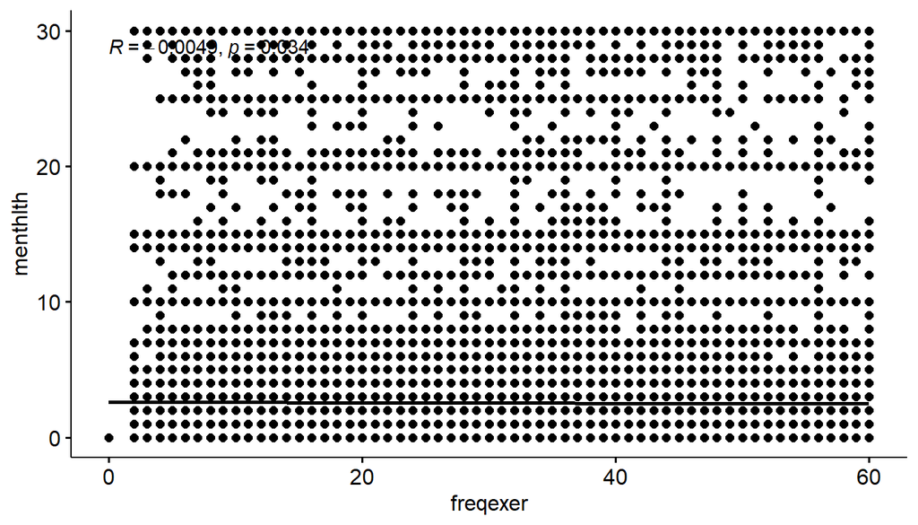

```r
fig_mental_freqexer
```

- Fig 2: scatter plot of phycial unwellness days and frequency of exercise

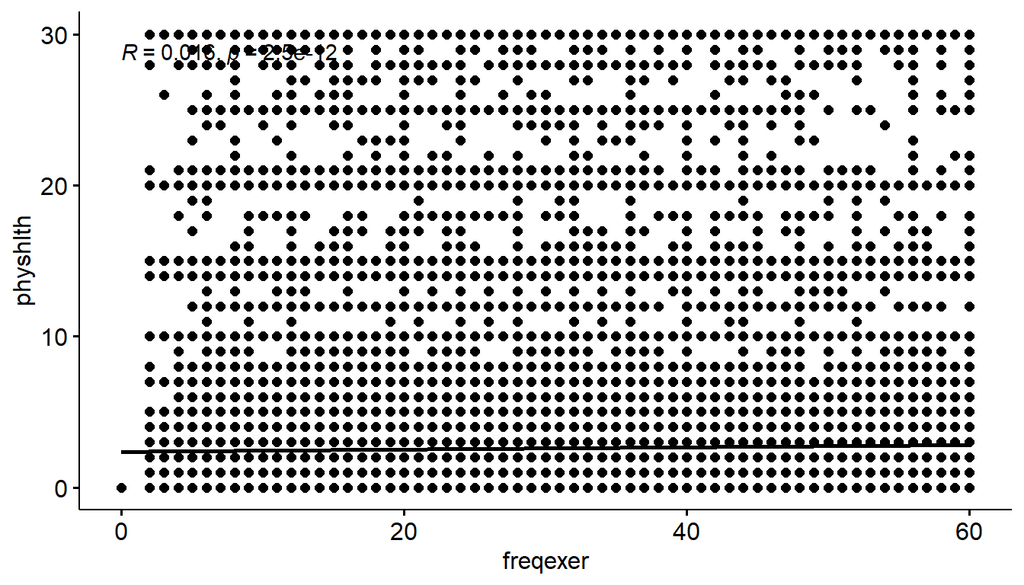

```r
fig_phy_freqexer
```

- Fig-3 Heat map of between number of days mentally not feeling well vs frequency of exercise days

```r
frequency_matrix <- dcast(mental_health, menthlth ~ freqexer)
```

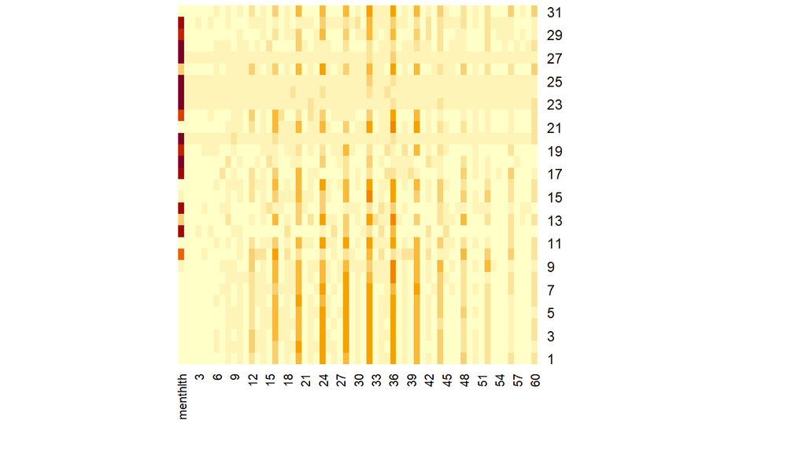

```r
x<-mental_health$menthlth
y<-mental_health$freqexer

heatmap(as.matrix(frequency_matrix), Rowv = NA, Colv = NA)
```

- Fig-4 Heat map of between number of days physically not feeling well vs number of execercise days

```r
frequency_matrix <- dcast(physical_health, physhlth ~ freqexer)
```

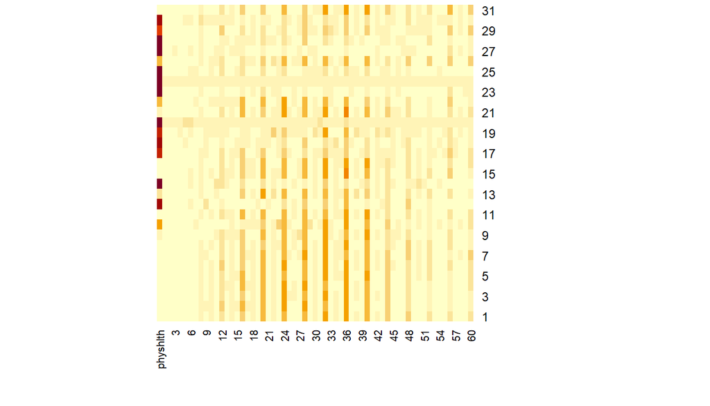

```r
x<-physical_health$physhlth
y<-physical_health$freqexer

heatmap(as.matrix(frequency_matrix), Rowv = NA, Colv = NA)
```

**Research question 2:**

- How dose diabete relate with body fat (weight, height, BMI) and sex?
- Variables:
  - _bmi5 : weight and height are correlated variables, instead of using raw height and weight, we use BMI to represent the objects’ body fat condition.
  - sex
  - diabetes3: (Ever Told You Have Diabetes)
    - For simplicity, we only consider objects in diabete 3 that answered yes or no.
- Relevance:
  - Diabetes is a chronic health condition and it affects the body ability to turn food into energy. We would like to investigate if overweight people have a higher possibility of getting diabetes.

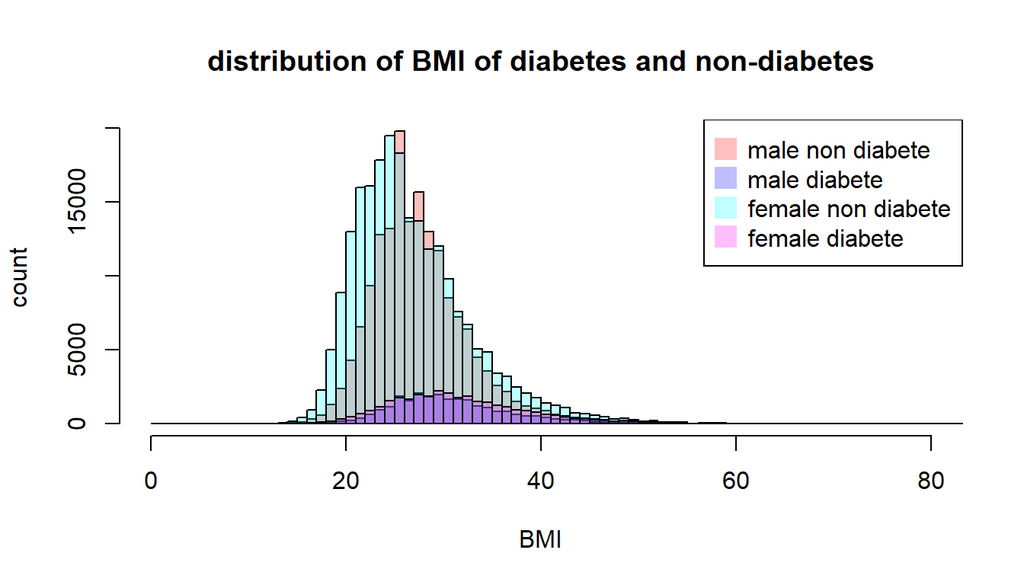

```r
convert_2_implied_decimal<- function(x){
  return (x/100)
}


valid_all<-select(brfss2013, sex, X_bmi5, diabete3)
valid_all<-valid_all[complete.cases(valid_all),]
valid_all<-valid_all[valid_all$diabete3 == 'Yes' | valid_all$diabete3 == 'No',]

valid_all$X_bmi5<- sapply(valid_all$X_bmi5, convert_2_implied_decimal)

valid_all$diabete_numeric[valid_all$diabete3 == 'Yes'] <- 1
valid_all$diabete_numeric[valid_all$diabete3 == 'No'] <- 2

male_section <- valid_all[valid_all$sex == 'Male',]

male_section_positive <- male_section[male_section$diabete_numeric==1,]
male_section_negative <- male_section[male_section$diabete_numeric==2,]

female_section <- valid_all[valid_all$sex == 'Female',]

female_section_positive <- female_section[female_section$diabete_numeric==1,]
female_section_negative <- female_section[female_section$diabete_numeric==2,]

#https://www.r-graph-gallery.com/190-mirrored-histogram.html
#par(mfrow=c(2,1))

#par(mar=c(0,5,3,3))
#hist(male_section_negative$X_bmi5, main="" , xlim=c(0,80), ylab="male non diabete", xlab="", ylim=c(0, 30000) , las=1 , col="tomato3"  , breaks=80)

#par(mar=c(5,5,0,3))
#hist(male_section_positive$X_bmi5, main="" , xlim=c(0,80), ylab="male diabete", xlab="BMI", ylim=c(3000, 0) , las=1 , col="tomato3"  , breaks=80)


# First distribution
hist(male_section_negative$X_bmi5, breaks=80, xlim=c(0,80), col=rgb(1,0,0,0.25), xlab="BMI",
     ylab="count", main="distribution of BMI of diabetes and non-diabetes" )

# Second with add=T to plot on top
hist(male_section_positive$X_bmi5, breaks=80, xlim=c(0,80), col=rgb(0,0,1,0.25), add=T)

# Third distribution
hist(female_section_negative$X_bmi5, breaks=80, xlim=c(0,80), col=rgb(0,1,1,0.25), add=T)

# Fourth with add=T to plot on top
hist(female_section_positive$X_bmi5, breaks=80, xlim=c(0,80), col=rgb(1,0,1,0.25), add=T)


# Add legend
legend("topright", legend=c("male non diabete","male diabete", "female non diabete", "female diabete"), col=c(rgb(1,0,0,0.25),
     rgb(0,0,1,0.25), rgb(0,1,1,0.25), rgb(1,0,1,0.25)), pt.cex=2, pch=15 )
```

**Research question 3:**

Ho: Null Hypothesis, there is no statistically significant relationship between them. Ha: Alternative Hypothesis, there are significant relationship between these variables.

```r
freq_per_month<- function(x){
  if(100< x & x <200) y <- 30 * (x - 100)
  else if(200< x & x<300) y <- 4 * (x - 200)
  else if(300< x & x<400) y <- (x - 300)
  else
    y <- 0
  return(y)
}
```

```r
valid_all<-select(brfss2013, educa, ssbfrut2, diabete3)
valid_all<-valid_all[complete.cases(valid_all),]
#convert to numeric
valid_all$educa <- as.numeric(valid_all$educa)
valid_all$freqsuda<- sapply(valid_all$ssbfrut2, freq_per_month)
#valid_all<-valid_all[valid_all$diabete3 == 'Yes' | valid_all$diabete3 == 'No',]
#valid_all$diabete_numeric[valid_all$diabete3 == 'Yes'] <- 1
#valid_all$diabete_numeric[valid_all$diabete3 == 'No'] <- 2
valid_all$diabete3 <- as.numeric(valid_all$diabete3)
```

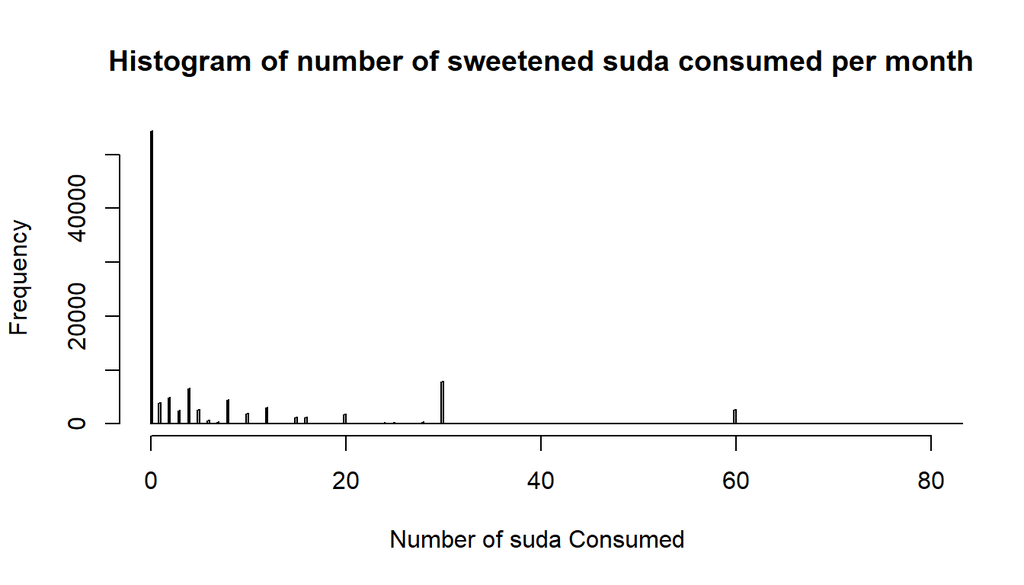

```r
hist(valid_all$freqsuda, main = "Histogram of number of sweetened suda consumed per month", xlab = "Number of suda Consumed ", ylab = "Frequency",
breaks=10000, xlim=c(0,80))
```

```r
valid_all_vars <- select(valid_all, educa, freqsuda, diabete3)
cor(valid_all_vars)
```

```
##               educa    freqsuda   diabete3
## educa     1.0000000 -0.10446364 0.11236878
## freqsuda -0.1044636  1.00000000 0.04699033
## diabete3  0.1123688  0.04699033 1.00000000
```

```r
lm <- lm(formula=valid_all_vars$diabete3~valid_all_vars$freqsuda+valid_all_vars$educa, data=valid_all_vars)
summary(lm)
```

```
##
## Call:
## lm(formula = valid_all_vars$diabete3 ~ valid_all_vars$freqsuda +
##     valid_all_vars$educa, data = valid_all_vars)
##
## Residuals:
##     Min      1Q  Median      3Q     Max
## -4.8751  0.1731  0.2078  0.3120  1.5534
##
## Coefficients:
##                          Estimate Std. Error t value Pr(>|t|)
## (Intercept)             2.347e+00  1.048e-02  224.06   <2e-16 ***
## valid_all_vars$freqsuda 1.697e-03  8.902e-05   19.07   <2e-16 ***
## valid_all_vars$educa    7.878e-02  2.069e-03   38.07   <2e-16 ***
## ---
## Signif. codes:  0 '***' 0.001 '**' 0.01 '*' 0.05 '.' 0.1 ' ' 1
##
## Residual standard error: 0.687 on 102566 degrees of freedom
## Multiple R-squared:  0.01611,    Adjusted R-squared:  0.01609
## F-statistic: 839.9 on 2 and 102566 DF,  p-value: < 2.2e-16
```

Discussion: - From the histogram of people drink soda, we can see that most people don’t drink sweetened soda. As we can see there is two spike on 30 and 60 as some people drink one per day, and some drink twice a day. - from the correlation analysis, we can see that education has is more correlated with diabetes (0.11) than number of soda comsumed (0.05). - From Multiple Linear regression model, we can see that the coefficient estimated for soda consumption frequency and education are both small for diabetes. But coefficient for education (0.078) is larger than that for soda (0.002). The Adjusted R-squared is also small, so two variable did not explain much for diabetes. Both variable have statifically significant t-values and p values.